# Introduction_3_loadfrequency

Hangjia Zhao

2023-08-22

# Load library

```r
library(pgxRpi)
```

## `pgxLoader` function

This function loads various data from `Progenetix` database.

The parameters of this function used in this tutorial:

- `type` A string specifying output data type. Available options are “biosample”, “individual”, “variant” or “frequency”.
- `output` A string specifying output file format. When the parameter `type` is “frequency”, available options are “pgxfreq” or “pgxmatrix” .
- `filters` Identifiers for cancer type, literature, cohorts, and age such as c(“NCIT:C7376”, “pgx:icdom-98353”, “PMID:22824167”, “pgx:cohort-TCGAcancers”, “age:>=P50Y”). For more information about filters, see the [documentation](https://docs.progenetix.org/beaconplus/#filters-filters-filtering-terms).
- `codematches` A logical value determining whether to exclude samples from child concepts of specified filters that belong to cancer type/tissue encoding system (NCIt, icdom/t, Uberon). If TRUE, retrieved samples only keep samples exactly encoded by specified filters. Do not use this parameter when `filters` include cancer-irrelevant filters such as PMID and cohort identifiers. Default is FALSE.

# Retrieve CNV frequency data

## Relevant parameters

type, output, filters, codematches

## The first output format (`output` = “pgxfreq”)

```r
freq_pgxfreq <- pgxLoader(type="frequency", output ='pgxfreq',
                         filters=c("NCIT:C4038","pgx:icdom-85003"))
```

The `meta` slot of this object looks like this

```r
freq_pgxfreq$meta
```

```
#>              code                            label sample_count
#> 1      NCIT:C4038             Lung Carcinoid Tumor          160
#> 2 pgx:icdom-85003 Infiltrating duct carcinoma, NOS        12621
#> 3           total                                         12781
```

The `data` slot contains a list of the CNV frequency data frames named by the corresponding filters. The data frame with the name ‘total’ is the concatenated data frames from all filters.

```r
names(freq_pgxfreq$data)
```

```
#> [1] "NCIT:C4038"      "pgx:icdom-85003" "total"
```

You can access the data frame with “pgxfreq” format of one filter from this list.

```r
print(dim(freq_pgxfreq$data[['NCIT:C4038']]))
```

```
#> [1] 3106    7
```

```r
head(freq_pgxfreq$data[['NCIT:C4038']])
```

```
#>      filters reference_name   start     end gain_frequency loss_frequency no
#> 1 NCIT:C4038              1       0  400000          0.625          1.875  1
#> 2 NCIT:C4038              1  400000 1400000          1.250          8.750  2
#> 3 NCIT:C4038              1 1400000 2400000          2.500          9.375  3
#> 4 NCIT:C4038              1 2400000 3400000          2.500         13.750  4
#> 5 NCIT:C4038              1 3400000 4400000          3.125         14.375  5
#> 6 NCIT:C4038              1 4400000 5400000          3.125         11.250  6
```

In the pgxfreq format, the whole genome (GRCh38) is partitioned into 3106 intervals or bins (the size of most bins is 1MB except a few bins close to telomeres).

- `filters`: identifiers for grouping.
- `reference_name`, `start` and `end` specify interval location in chromosome.
- `gain_frequency` and `loss_frequency` indicate the percent values across samples (%) for gains and losses overlapping the interval, respectively.

The parameter `codematches` determines whether the calculation of CNV frequency excludes samples from child terms.

## The second output format (`output` = “pgxmatrix”)

Choose 8 NCIT codes of interests that correspond to different tumor types

```r
code <-c("C3059","C3716","C4917","C3512","C3493","C3771","C4017","C4001")
# add prefix for query
code <- sub(".",'NCIT:C',code)
```

load data with the specified code

```r
freq_pgxmatrix <- pgxLoader(type='frequency',output = 'pgxmatrix',filters=code)
```

The `meta` slot of this object looks like this

```r
freq_pgxmatrix$meta
```

```
#>         code                           label sample_count
#> 1 NCIT:C3059                          Glioma         8183
#> 2 NCIT:C3716 Primitive Neuroectodermal Tumor         2214
#> 3 NCIT:C4917       Lung Small Cell Carcinoma          558
#> 4 NCIT:C3512             Lung Adenocarcinoma         4664
#> 5 NCIT:C3493    Lung Squamous Cell Carcinoma         1938
#> 6 NCIT:C3771        Breast Lobular Carcinoma          904
#> 7 NCIT:C4017         Breast Ductal Carcinoma        10254
#> 8 NCIT:C4001   Breast Inflammatory Carcinoma           27
#> 9      total                                        28742
```

The `data` slot contains a list of the nine CNV frequency data frames. One of these nine data frames looks like this

```r
freq_pgxmatrix$data[['NCIT:C3059']][,c(1:4,3108:3110)]
```

```
#>      filters X1.0.400000.DUP X1.400000.1400000.DUP X1.1400000.2400000.DUP
#> 1 NCIT:C3059            3.41                 8.457                 10.644
#>   X1.0.400000.DEL X1.400000.1400000.DEL X1.1400000.2400000.DEL
#> 1           5.255                  7.76                 10.119
```

In the data frame with “pgxmatrix” format, `filters` is the same as that in the “pgxfreq” format. It’s followed by all “gain status” columns (3106 intervals) plus all “loss status” columns (3106 intervals). For example, if the column `X1.400000.1400000.DUP` is 8.457, it means that 8.457% samples from the corresponding filter having one or more duplication events in the genomic interval in chromosome 1: 400000-1400000.

Note: it is different from CNV status matrix introduced in [Introduction_2_loadvariants](https://htmlpreview.github.io/?https://github.com/progenetix/pgxRpi/blob/main/vignettes/Introduction_2_loadvariants.html). Value in this matrix is **percentage (%) of samples** having one or more CNVs overlapped with the binned interval while the value in CNV status matrix is **fraction in individual samples** to indicate how much the binned interval overlaps with one or more CNVs in the individual sample.

You can also access the total data frame for analyzing multiple frequency sets.

```r
freq_pgxmatrix$data[['total']][,c(1:4,3108:3110)]
```

```
#>      filters X1.0.400000.DUP X1.400000.1400000.DUP X1.1400000.2400000.DUP
#> 1 NCIT:C3059           3.410                 8.457                 10.644
#> 2 NCIT:C3716           3.568                 7.678                  8.988
#> 3 NCIT:C4917          11.470                25.448                 24.373
#> 4 NCIT:C3512           1.951                 6.089                  5.832
#> 5 NCIT:C3493           5.315                 8.978                  6.553
#> 6 NCIT:C3771           0.996                 2.434                  2.655
#> 7 NCIT:C4017           8.660                11.059                  8.553
#> 8 NCIT:C4001           3.704                 3.704                  3.704
#>   X1.0.400000.DEL X1.400000.1400000.DEL X1.1400000.2400000.DEL
#> 1           5.255                 7.760                 10.119
#> 2          15.041                21.409                 26.107
#> 3           7.527                12.366                 14.158
#> 4           2.744                 5.489                  5.875
#> 5           5.418                15.738                 16.202
#> 6           2.102                 5.863                  5.310
#> 7           7.578                13.039                 16.491
#> 8          14.815                25.926                 25.926
```

## Select ids of interests from original object

It is realized by `pgxFreqselect` function.

This function can select filters of interests from input object and return a new object with selected filters.

The parameters of this function:

- `data`: CNV frequency data returned by `pgxLoader` function.
- `filters`: identifiers of interests such as c(“NCIT:C7376”,“pgx:icdom-98353”).

```r
freq_sel <- pgxFreqselect(data=freq_pgxmatrix,
                          filters = c("NCIT:C4917","NCIT:C3512","NCIT:C3493"))
freq_sel$data$total[,c(1:5)]
```

```
#>      filters X1.0.400000.DUP X1.400000.1400000.DUP X1.1400000.2400000.DUP
#> 1 NCIT:C4917          11.470                25.448                 24.373
#> 2 NCIT:C3512           1.951                 6.089                  5.832
#> 3 NCIT:C3493           5.315                 8.978                  6.553
#>   X1.2400000.3400000.DUP
#> 1                 29.032
#> 2                 12.693
#> 3                 10.475
```

# Visualization of CNV frequency data using ‘pgxfreq’ format

## `pgxFreqplot` function

This function provides CNV frequency plots by genome or chromosomes as you request.

The parameters of this function:

- `data`: frequency object returned by `pgxLoader` function or individual frequency matrix with ‘pgxfreq’ format. In the returned object by `pgxLoader`, the frequency matrices in `data` slot must be stored as `pgxfreq` format, which can be specified by `output` parameter of `pgxLoader` function.
- `chrom`: a vector with chromosomes to be plotted. If NULL, return the plot by genome. If specified the frequencies are plotted with one panel for each chromosome. Default is NULL.
- `layout`: number of columns and rows in plot. Only used in plot by chromosome. Default is c(1,1).
- `filters`: Index or string value to indicate which filter to be plotted. The length of filters is limited to one if the parameter `circos` is False. Default is the first filter.
- `circos`: a logical value to indicate if return a circos plot. If TRUE, it can return a circos plot with multiple group ids for display and comparison. Default is FALSE.
- `highlight`: Indices of genomic bins to be highlighted with red color.
- `assembly`: A string specifying which genome assembly version should be applied to CNV frequency plotting. Allowed options are “hg19”, “hg38”. Default is “hg38” (genome version used in Progenetix).

## CNV frequency plot by genome

### Input is an object.

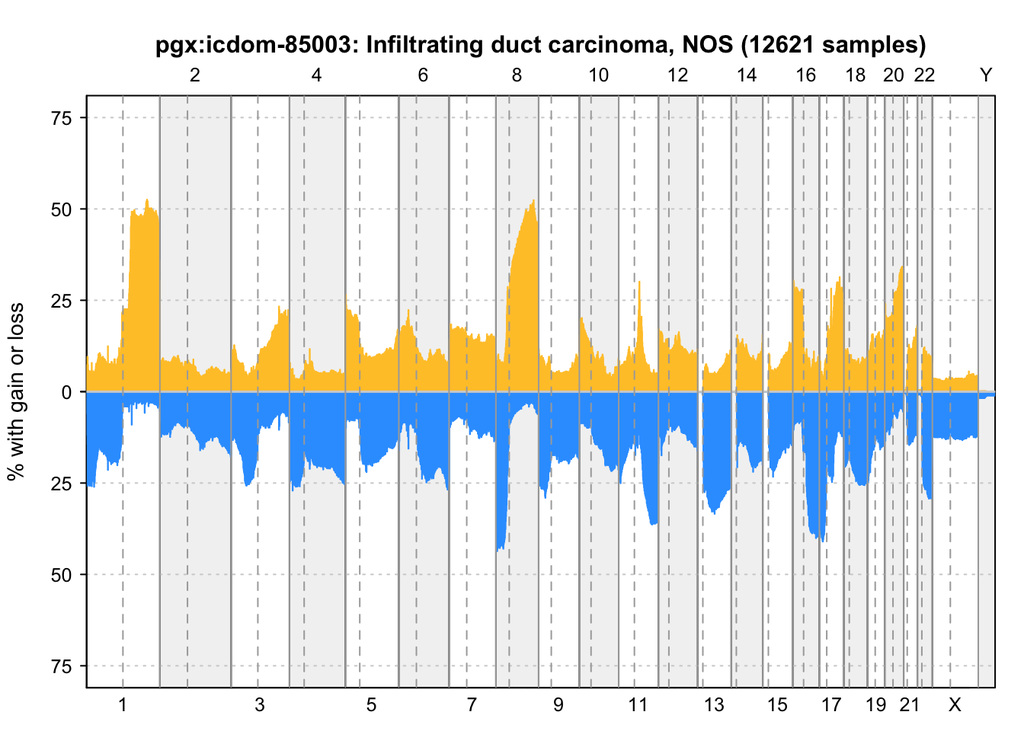

```r
pgxFreqplot(freq_pgxfreq, filters='pgx:icdom-85003')
```

### Input is individual frequency data.

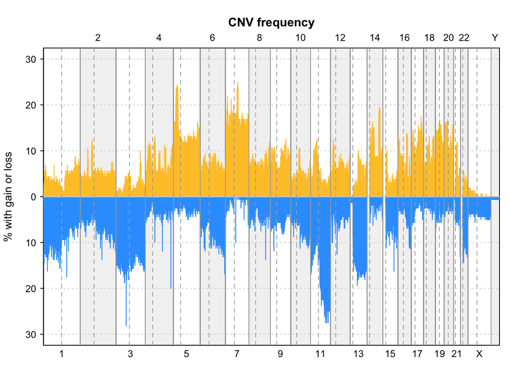

```r
pgxFreqplot(freq_pgxfreq$data[["NCIT:C4038"]])
```

By default, the supported genome for plotting is GRCh38. You can set the `assembly` parameter to ‘hg19’ if the plotting genome is GRCh37.

## CNV frequency plot by chromosomes

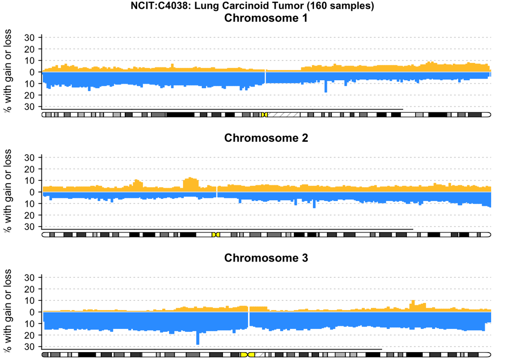

```r
pgxFreqplot(freq_pgxfreq, filters='NCIT:C4038',chrom=c(1,2,3), layout = c(3,1))
```

## CNV frequency circos plot

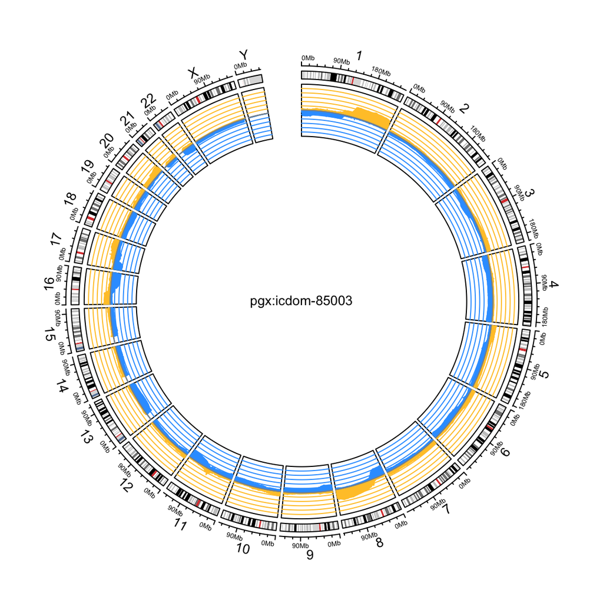

```r
pgxFreqplot(freq_pgxfreq, filters='pgx:icdom-85003', circos = TRUE)
```

The circos plot also supports multiple group comparison

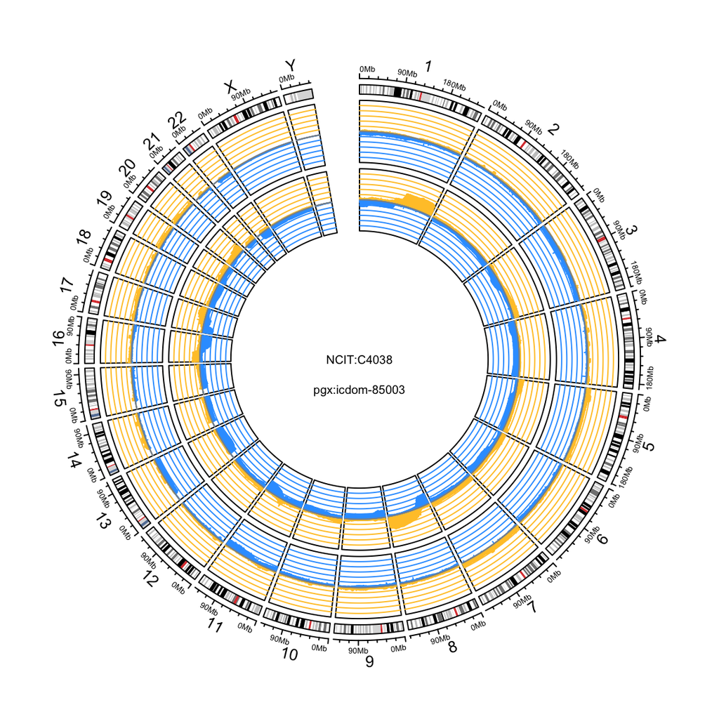

```r
pgxFreqplot(freq_pgxfreq,filters= c("NCIT:C4038","pgx:icdom-85003"),circos = TRUE)
```

## Highlight interesting genomic intervals

If you want to look at the CNV frequency at specific genomic bins, you can use `highlight` parameter. For example, when you are interested in CNV pattern of CCND1 gene in samples with infiltrating duct carcinoma (icdom-85003). You could first find the genomic bin where CCND1 (chr11:69641156-69654474) is located.

```r
# Extract the CNV frequency data frame of samples from 'icdom-85003' from
# the previously returned object
freq_IDC <- freq_pgxfreq$data$`pgx:icdom-85003`
# search the genomic bin where CCND1 is located
bin <- which(freq_IDC$reference_name == 11 & freq_IDC$start <= 69641156 &
             freq_IDC$end >= 69654474)
freq_IDC[bin,]
```

```
#>              filters reference_name    start      end gain_frequency
#> 4993 pgx:icdom-85003             11 69400000 70400000         30.124
#>      loss_frequency   no
#> 4993          8.993 1887
```

Then you could highlight this genomic bin like this

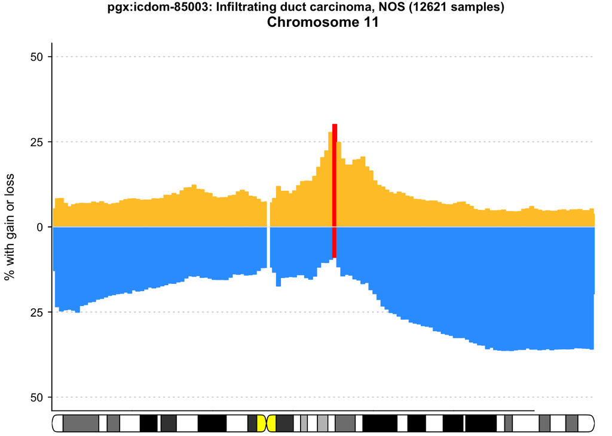

```r
pgxFreqplot(freq_pgxfreq,filters = 'pgx:icdom-85003', chrom = 11,highlight = bin)
```

Note: For CNV analysis of specific genes, the highlighted plot is rough as a reference, because the bin size in frequency plots is 1MB, which is possible to cover multiple genes.

The highlighting is also available for genome plots and circos plots. And you could highlight multiple bins by a vector of indices.

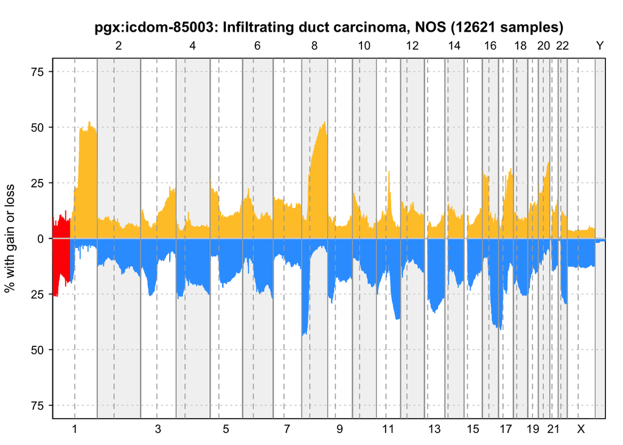

```r
pgxFreqplot(freq_pgxfreq,filters = 'pgx:icdom-85003',highlight = c(1:100))
```

# Clustering of CNV frequency data using ‘pgxmatrix’ format

## Hierarchical clustering

Use hierarchical clustering to cluster the tumor types which are picked before by NCIt code.

```r
# extract CNV frequency data from `total` slot
freq_mat <- freq_pgxmatrix$data[['total']][,2:dim(freq_pgxmatrix$data[['total']])[2]]
rownames(freq_mat) <- freq_pgxmatrix$data[['total']]$filters
# do clustering
dist_mat <- dist(freq_mat, method = 'euclidean')
hclust_res <- hclust(dist_mat, method = "ward.D")
```

The clustering result is shown below.

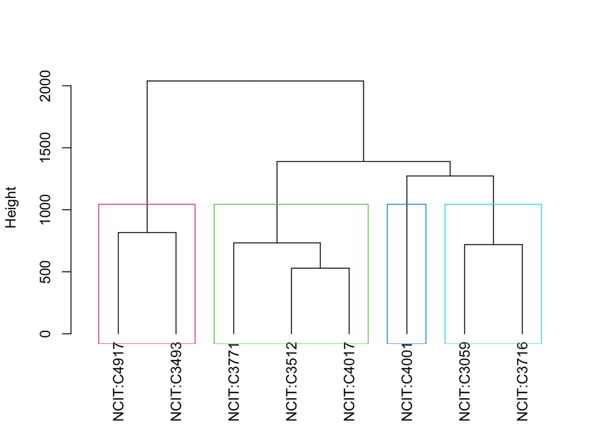

```r
hcd <- as.dendrogram(hclust_res)
plot(hcd, type = "rectangle", ylab = "Height")
# Based on the plot, the number of clusters is set to 4.
cut<- cutree(hclust_res, k = 4)
rect.hclust(hclust_res , k = 4, border = 2:6)
```

## Merge frequency matrix

Merge the frequency matrix by calculating the difference between gain frequency and loss frequency per interval (gain-loss)

```r
diff_mat <- freq_mat[,1:3106]-freq_mat[,3107:6212]
```

Sort the merged matrix by clustering membership

```r
sort_idx <- order(cut)
cut <- cut[sort_idx]
diff_mat <- diff_mat[sort_idx,]
```

## Get metadata (label, sample number)

From the `meta` slot of the object

```r
meta <- freq_pgxmatrix$meta[sort_idx,]
```

## Plot heatmap

Plot a heatmap to show the merged matrix. The color in the rowside shows cluster membership calculated by the original frequency matrix

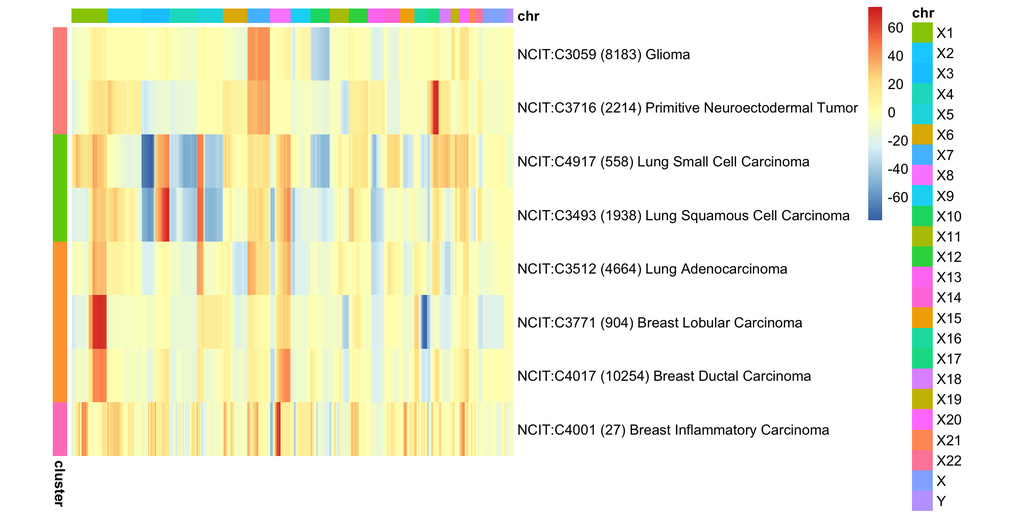

```r
library("RColorBrewer")
library('pheatmap')
rownames(diff_mat) <- paste(meta[,1], paste0("(",meta[,3],")"),meta[,2])

parlength <- 100
myBreaks <- c(seq(min(diff_mat), 0, length.out=ceiling(parlength/2) + 1),
              seq(max(diff_mat)/parlength, max(diff_mat), length.out=floor(parlength/2)))

annotation_row <- data.frame(cluster=factor(cut))
annotation_col <- data.frame(chr=factor(substring(colnames(diff_mat),1,
                                                  last=regexpr("\\.", colnames(diff_mat))-1),
                                        levels = c(gsub('^','X',seq(1,22)), 'X','Y')))
rownames(annotation_col) <- colnames(diff_mat)
rownames(annotation_row) <- rownames(diff_mat)

pheatmap(as.matrix(diff_mat), scale = "none",cluster_cols = FALSE, cluster_rows = FALSE,
         width = 8,height = 10,cellwidth=0.1,breaks=myBreaks,show_colnames=FALSE ,
         annotation_row = annotation_row,annotation_col = annotation_col,annotation_legend=TRUE)
```